# Computer Lab 01 — `BRugs`

Berwin A Turlach

March 06, 2021

# Introduction

If you are on a system on which you cannot run `OpenBUGS` but the R package `BRugs` is available (e.g. a Linux operating system), then the following shows how to run the two computer lab examples using the `BRugs` package.

# Exercise 1

Assume we have the `BUGS` code for that example in a file called `Ex1.bug`:

```
model {
  Y ~ dbin(0.5, 8)
  P2 <- step(2.5 -Y ) # does Y = 2, 1, or 0?
}
```

First, we load the package `BRugs`:

```r
library(BRugs)
```

Then we check whether the code in the file `Ex1.bug` is syntactically correct:

```r
modelCheck("Ex1.bug")
```

```
model is syntactically correct
```

Depending on where you store the downloaded files on the computers in the Mathematics Computing Laboratory, the above command might throw an error and complain that the file `Ex1.bug` cannot be found. This presumably happens as the command was given a path to the file and `R` (and `RStudio`) do not support UNC paths. Make sure that you point `RStudio` to the directory where you have stored the file via a non UNC path, as discussed in the lectures.

Next, we compile one chain:

```r
modelCompile(numChains=1)
```

```
model compiled
```

And generate initial values for that one chain:

```r
modelGenInits()
```

Next, we specify the two nodes that we want to monitor:

```r
samplesSet(c("Y", "P2"))
```

```
monitor set for variable 'Y'
monitor set for variable 'P2'
```

and then update the model 10,000 times:

```r
modelUpdate(10000)
```

```
10000 updates took 0 s
```

The statistics on each monitored node we can obtain as follows:

```r
samplesStats("*")
```

|  | mean | sd | MC_error | val2.5pc | median | val97.5pc | start | sample |
| --- | --- | --- | --- | --- | --- | --- | --- | --- |
| P2 | 0.1415 | 0.3485 | 0.003267 | 0 | 0 | 1 | 1 | 10000 |
| Y | 4.0050 | 1.4170 | 0.011690 | 1 | 4 | 7 | 1 | 10000 |

While the empirical densities of the simulated values are produced by the following command:

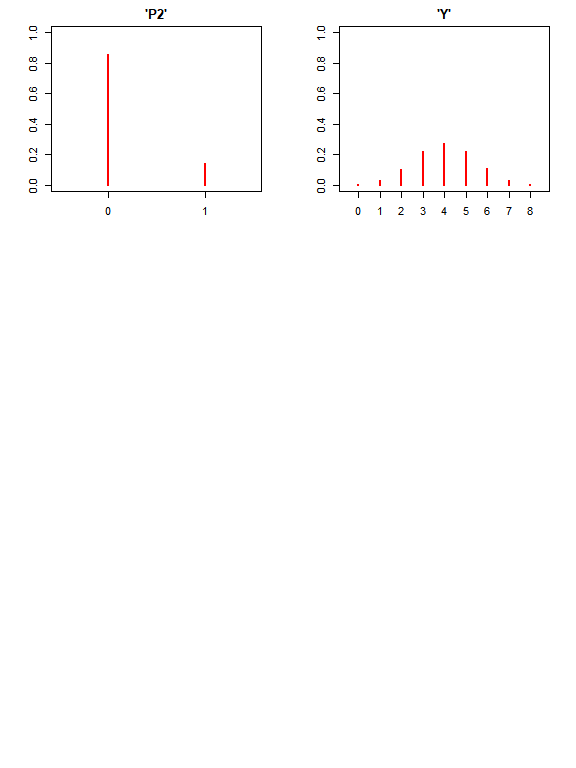

```r
samplesDensity("*", ask = FALSE)
```

# Exercise 2

Assume we have the `BUGS` code for that example in a file called `Ex2.bug`:

```
model {
  for(i in 1:20) {
     Y[i] ~ dgamma(4, 0.04)
  }
  cum[1] <- Y[1]
  for(i in 2:20) {
    cum[i] <- cum[i-1] + Y[i]
  }
  for(i in 1:20) {
    cum.step[i] <- i*step(1000 - cum[i])
  }
  number <- ranked(cum.step[], 20)  # maximum number in cum.step
  check  <- equals(cum.step[20], 0) # always 1 if I=20 big enough
}
```

First, we load the package `BRugs`:

```r
library(BRugs)
```

```r
modelCheck("Ex2.bug")
```

```
model is syntactically correct
```

Next, we compile one chain:

```r
modelCompile(numChains=1)
```

```
model compiled
```

And generate initial values for that one chain:

```r
modelGenInits()
```

```r
samplesSet(c("number", "Y[1]", "check"))
```

```
monitor set for variable 'number'
monitor set for variable 'Y[1]'
monitor set for variable 'check'
```

and then update the model 10,000 times:

```r
modelUpdate(10000)
```

```
10000 updates took 0 s
```

The statistics on each monitored node we can obtain as follows:

```r
samplesStats("*")
```

|  | mean | sd | MC_error | val2.5pc | median | val97.5pc | start | sample |
| --- | --- | --- | --- | --- | --- | --- | --- | --- |
| Y[1] | 100.100 | 49.940 | 4.840e-01 | 26.87 | 92.05 | 219.2 | 1 | 10000 |
| check | 1.000 | 0.000 | 1.000e-12 | 1.00 | 1.00 | 1.0 | 1 | 10000 |
| number | 9.642 | 1.626 | 1.586e-02 | 7.00 | 10.00 | 13.0 | 1 | 10000 |

While the empirical densities of the simulated values are produced by the following command:

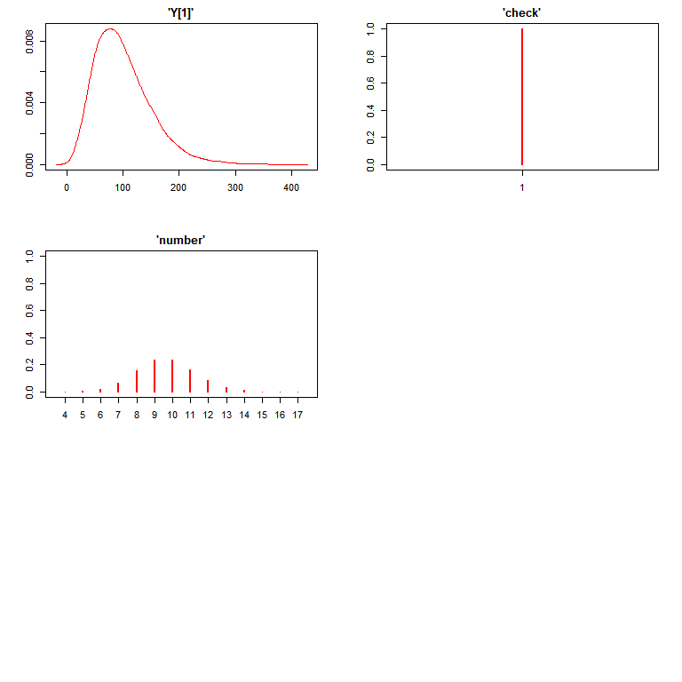

```r
samplesDensity("*", ask = FALSE)
```